# Bilan Dijon

**DATE DU DERNIER EXPORT DE DONNEES : 26 juin 2024**

## Chiffres clés

**Tableau participation**

| Protocole | Sites | Participants | Participations | Participations vides |
| --- | --- | --- | --- | --- |
| Aspifaune | 31 | 1 | 33 | 1 |
| Noctambules | 39 | 1 | 81 | 3 |
| Opération escargots | 4 | 2 | 5 | 0 |

**Répartition participants/protocoles**

Permet de rendre compte de l’overlap de participation entre protocoles. Combien de participants ont appliqué plusieurs protocoles Qubs ?

|  | Nombre de participants |
| --- | --- |
| aspifaune | 0 |
| escargots | 1 |
| noctambules | 0 |
| aspifaune.noctambule | 0 |
| aspifaune.escargots | 0 |
| noctambules.escargots | 0 |
| aspifaune.noctambules.escargots | 1 |

**Tableau observations**

| Protocole | Taxons Qubs différents | Taxons identifiés | Taxons non identifiés | Pourcentage taxons validés | Nombre de photos |
| --- | --- | --- | --- | --- | --- |
| Aspifaune | 58 | 97 | 4 | 33.66 | 95 |
| Noctambules | 70 | 174 | 12 | 34.95 | 184 |
| Opération escargots | 5 | 14 | 3 | 17.65 | 16 |

## Stats spéciales par protocole

**Aspifaune**

Dans le cadre du protocole Aspifaune on totalise 2.0625 m² de surface totale aspirée !

**Noctambules**

Dans le cadre du protocole Noctambules on peut fournir la durée totale de pose des gobelets la nuit : 1508.41666666667 heures.

Sinon je trouve que c’est plus parlant de donner le nombre de nuits différentes échantillonnées : 43 nuits échantillonnées depuis le lancement.

**Opération escargots**

- Nombre total d’individus observés : 83
- Nombre de taxons différents observés : 5
- Nombre de taxons différents observés et validés : 2
- Nombre d’abris : 4 (1 Coupelles ; 3 Planches)

## Communauté Qubs

**Intractions au total**

Ce tableau donne pour chaque protocole le **nombre total** de validations, de suggestions, de ré-identifications et de commentaires sur participations.

| Protocole | Validations | Suggestions | Ré-identifications | Commentaires participation |
| --- | --- | --- | --- | --- |
| Aspifaune | 140 | 53 | 22 | 38 |
| Noctambules | 237 | 72 | 10 | 19 |
| Opération escargots | 12 | 5 | 0 | 4 |

**Participant.es impliqués**

Ce tableau donne pour chaque protocole le **nombre de participant.es** ayant fait des validations, des suggestions, des ré-identifications ou des commentaires sur participation

| Protocole | Validations | Suggestions | Ré-identifications | Commentaires participation |
| --- | --- | --- | --- | --- |
| Aspifaune | 15 | 11 | 1 | 4 |
| Noctambules | 13 | 5 | 1 | 4 |
| Opération escargots | 5 | 4 | 0 | 1 |

## Top taxons

**Top taxons validés**

| taxon | Aspifaune | Noctambules | Opération escargots | Qubs |
| --- | --- | --- | --- | --- |
| L'Anchomène des champs | 0 | 1 | 0 | 1 |
| L'Armadille à long museau | 0 | 2 | 0 | 2 |
| L'Elégante striée | 0 | 2 | 0 | 2 |
| L'Escargot turc | 1 | 0 | 1 | 2 |
| L'Orcheselle ceinturée | 0 | 4 | 0 | 4 |
| La Coccinelle à 22 Points | 1 | 0 | 0 | 1 |
| La Coccinelle à 7 points | 1 | 0 | 0 | 1 |
| La Fourmi des pelouses | 0 | 1 | 0 | 1 |
| La Philoscie des mousses | 0 | 7 | 0 | 7 |
| Le Carabe doré | 0 | 1 | 0 | 1 |

[output cut: 37 more lines]

**Top taxons tout compris**

| taxon | Aspifaune | Noctambules | Opération escargots | Qubs |
| --- | --- | --- | --- | --- |
| L'Anchomène des champs | 0 | 1 | 0 | 1 |
| L'Armadille à long museau | 0 | 2 | 0 | 2 |
| L'Elégante striée | 0 | 2 | 0 | 2 |
| L'Escargot turc | 1 | 1 | 2 | 4 |
| L'Orcheselle ceinturée | 0 | 5 | 0 | 5 |
| L'Orcheselle jaune | 0 | 1 | 0 | 1 |
| L'Épeire des fissures | 1 | 0 | 0 | 1 |
| La Coccinelle à 22 Points | 1 | 0 | 0 | 1 |
| La Coccinelle à 7 points | 1 | 0 | 0 | 1 |
| La Fourmi Acrobate à tête rouge | 0 | 1 | 0 | 1 |

[output cut: 87 more lines]

## Camemberts taxo

Cette partie fournit l’information sur la distribution des observations (occurrence) selon différents regroupements d’espèces. Les proportions sont calculées à partir de l’ensemble des observations (sans prendre en compte la validation)

Pour Aspifaune, Noctambules et l’ensemble des données Qubs, sont fournis un donut chart de la distribution des observations en 7 groupes, un tableau des données associées (Regroupement 2a) puis un tableau de la distribution des observations en 12 groupes.

Pour Opération escargots : la distribution des observations entre escargots et limaces.

**Qubs**

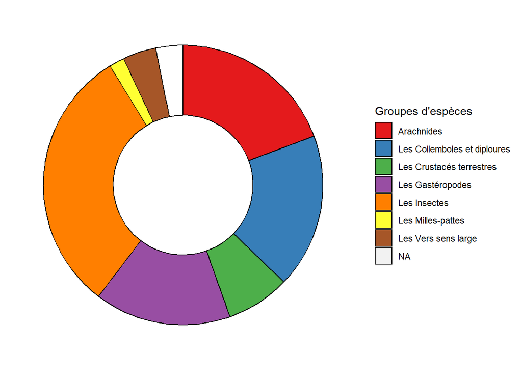

| Regroupement2a | Observations | Observations validées | Proportion groupe |
| --- | --- | --- | --- |
| Arachnides | 55 | 11 | 0.193 |
| Les Collemboles et diploures | 51 | 27 | 0.179 |
| Les Crustacés terrestres | 21 | 10 | 0.074 |
| Les Gastéropodes | 45 | 9 | 0.158 |
| Les Insectes | 88 | 37 | 0.309 |
| Les Milles-pattes | 5 | 2 | 0.018 |
| Les Vers sens large | 11 | 2 | 0.039 |
|  | 9 | 4 | 0.032 |

| Regroupement2b | Observations | Observations validées | Proportion groupe |
| --- | --- | --- | --- |
| Les Acariens | 5 | 1 | 0.018 |
| Les Annélides | 11 | 2 | 0.039 |
| Les Araignées | 49 | 9 | 0.172 |
| Les Autres arachnides | 1 | 1 | 0.004 |
| Les Autres insectes | 18 | 7 | 0.063 |
| Les Carabes et Staphylins | 35 | 16 | 0.123 |
| Les Collemboles et diploures | 51 | 27 | 0.179 |
| Les Crustacés | 21 | 10 | 0.074 |
| Les Escargots | 33 | 8 | 0.116 |
| Les Fourmis | 35 | 14 | 0.123 |

[output cut: 3 more lines]

**Aspifaune**

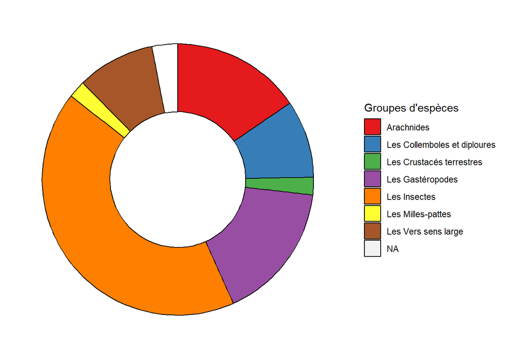

| Regroupement2a | Observations | Observations validées | Proportion groupe |
| --- | --- | --- | --- |
| Arachnides | 15 | 3 | 0.155 |
| Les Collemboles et diploures | 9 | 5 | 0.093 |
| Les Crustacés terrestres | 2 | 1 | 0.021 |
| Les Gastéropodes | 16 | 3 | 0.165 |
| Les Insectes | 41 | 17 | 0.423 |
| Les Milles-pattes | 2 | 1 | 0.021 |
| Les Vers sens large | 9 | 2 | 0.093 |
|  | 3 | 2 | 0.031 |

| Regroupement2b | Observations | Observations validées | Proportion groupe |
| --- | --- | --- | --- |
| Les Acariens | 2 | 0 | 0.021 |
| Les Annélides | 9 | 2 | 0.093 |
| Les Araignées | 13 | 3 | 0.134 |
| Les Autres insectes | 11 | 5 | 0.113 |
| Les Carabes et Staphylins | 9 | 4 | 0.093 |
| Les Collemboles et diploures | 9 | 5 | 0.093 |
| Les Crustacés | 2 | 1 | 0.021 |
| Les Escargots | 16 | 3 | 0.165 |
| Les Fourmis | 21 | 8 | 0.216 |
| Les Milles-pattes | 2 | 1 | 0.021 |

[output cut: 1 more lines]

**Noctambules**

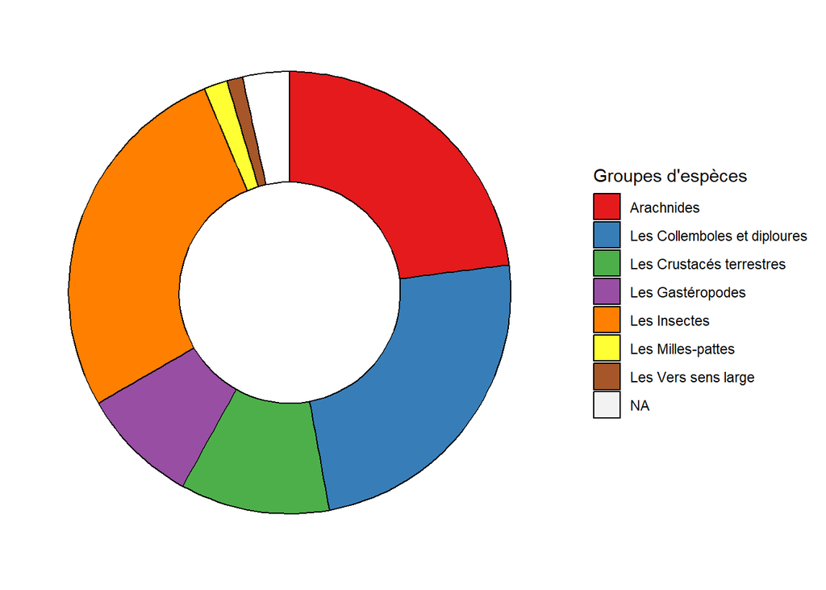

| Regroupement2a | Observations | Observations validées | Proportion groupe |
| --- | --- | --- | --- |
| Arachnides | 40 | 8 | 0.23 |
| Les Collemboles et diploures | 42 | 22 | 0.241 |
| Les Crustacés terrestres | 19 | 9 | 0.109 |
| Les Gastéropodes | 15 | 3 | 0.086 |
| Les Insectes | 47 | 20 | 0.27 |
| Les Milles-pattes | 3 | 1 | 0.017 |
| Les Vers sens large | 2 | 0 | 0.011 |
|  | 6 | 2 | 0.034 |

| Regroupement2b | Observations | Observations validées | Proportion groupe |
| --- | --- | --- | --- |
| Les Acariens | 3 | 1 | 0.017 |
| Les Annélides | 2 | 0 | 0.011 |
| Les Araignées | 36 | 6 | 0.207 |
| Les Autres arachnides | 1 | 1 | 0.006 |
| Les Autres insectes | 7 | 2 | 0.04 |
| Les Carabes et Staphylins | 26 | 12 | 0.149 |
| Les Collemboles et diploures | 42 | 22 | 0.241 |
| Les Crustacés | 19 | 9 | 0.109 |
| Les Escargots | 7 | 2 | 0.04 |
| Les Fourmis | 14 | 6 | 0.08 |

[output cut: 3 more lines]

**Opération escargots**

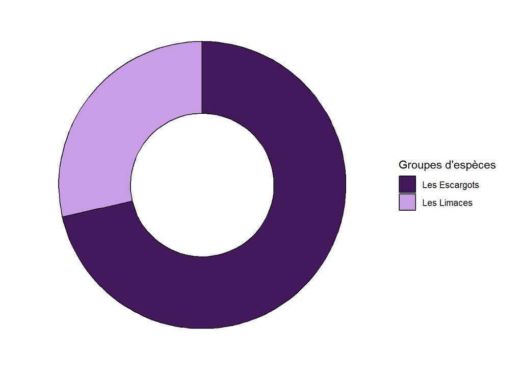

| Regroupement2b | Observations | Observations validées | Proportion groupe |
| --- | --- | --- | --- |
| Les Escargots | 10 | 3 | 0.714 |
| Les Limaces | 4 | 0 | 0.286 |

## Carte des sites

Une carte simplifiée avec l’ensemble des sites d’échantillonnages (tous protocoles confondus).

[interactive chart not shown]

## Types de sites

Ci-dessous la répartition des types de sites ayant participé à Qubs, tous protocoles confondus

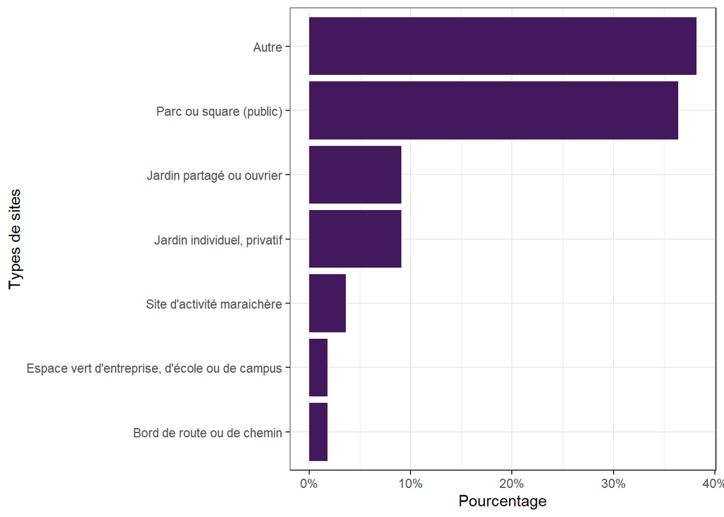

Ci-dessous la répartition des types de sites en fonction des protocoles

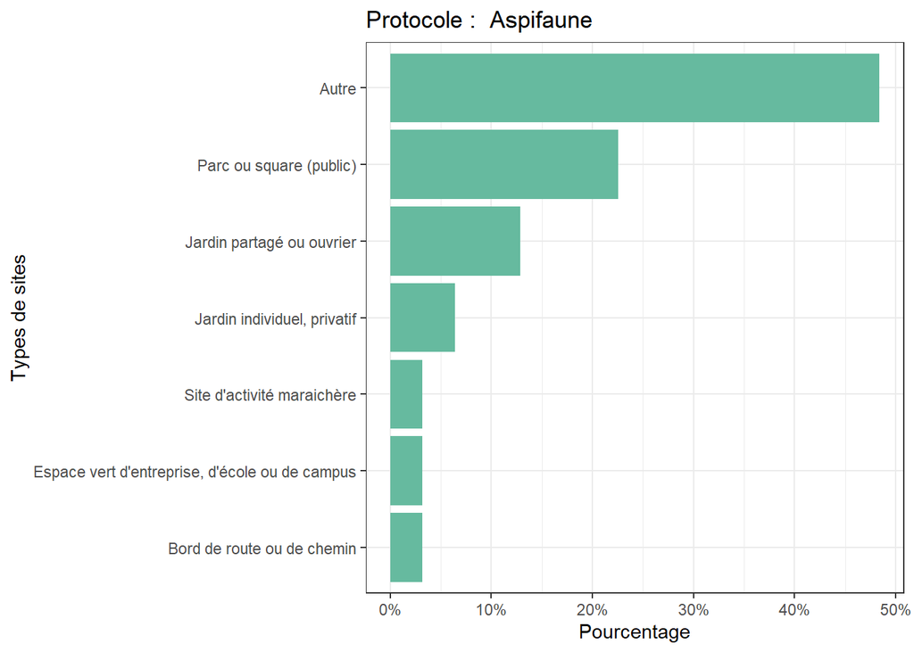

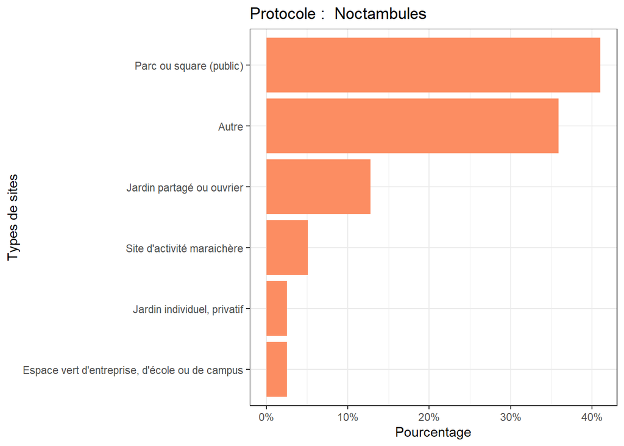

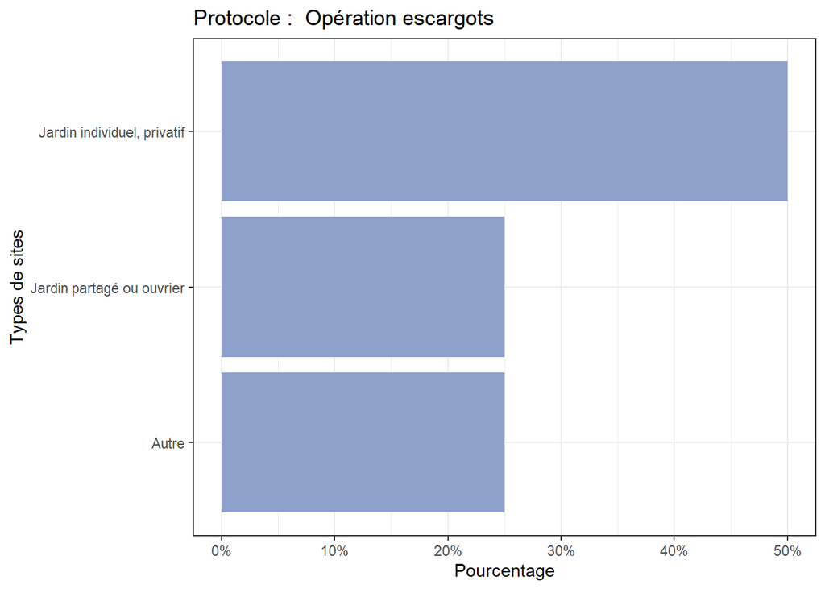